# Accountability and Information 1

Final Project Essentials: Fixed Effects

Jeremy Springman

University of Pennsylvania

**Global Development**: Intermediate Topics in Politics, Policy, and Data

PSCI 3200 - Spring 2025

# Logistics

## Assignments

- Today
  - de la Sierra (2020)
- Tuesday (3/26)
  - Jablonski and Seim (2023)
  - Questions about Data Assignment 1
- Thursday (3/28)
  - Data Assignment 1 Due
  - Readings on Accountability and Information

## Agenda

1. de la Sierra (2020)
2. Final Project Essentials: Interaction terms and Fixed Effects
3. Data Assignment 1

# de la Sierra (2020)

## Background

**What is political accountability?**

- Answerability
- Enforceability

## Background

**What is a state?**

- An entity with a monopoly on the legitimate use of physial violence
- Capacity to act as the sole arbiter and enforcer of law and order

## Background

**What are a state’s essential functions?**

1. War making: eliminating external rivals
2. State making: Eliminating internal rivals
3. Protection: Protecting clients
4. Extraction: Acquiring resources

## Background

**State formation**

- States have their origins as armed actors
- The most successful armed actors became states
- Where armed actors establish states depends on their ability to tax
- Taxation induces proto-accountability: more wealthy people means more tax revenue
- States lead to the emergence of growth

**What is the distinction between roving and stationary bandits?**

## Background

**The resource curse**

- Abundant natural resources are associated with lower growth, more conflict, and worse human outcomes?
- Why might abundant natural resources reduce political accountability?

## Theory

**Observability and incentives**

## Data

**Sample**

- Panel data on village histories (1995-2013)
- 650 locations

**Outcomes**

- State formation: Stationary bandit, output taxation, sophisticated taxation, security services, fiscal and judicial administration
- Population welfare: Savings, weddings, migrants

## Research Design

- Demand shocks for two resources
  - Coltan is observable
  - Gold is not observable
- Exogenous timing of mineral price changes

## Findings

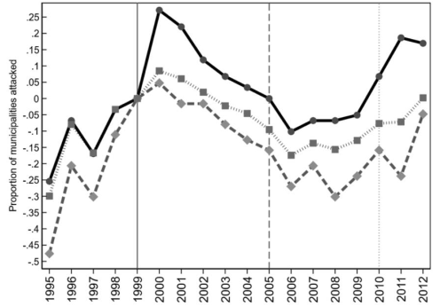

## Findings

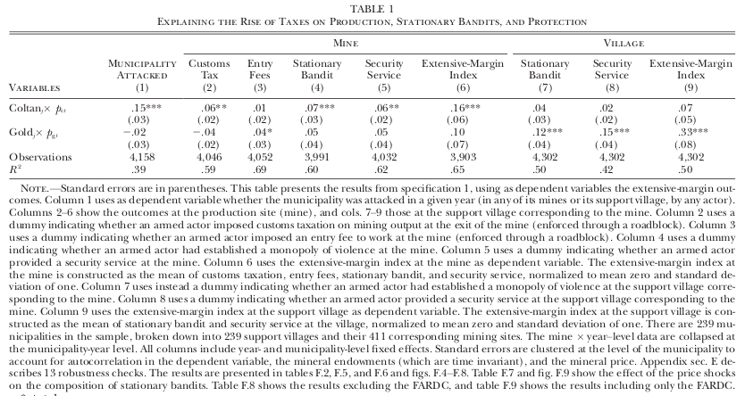

## Findings

- Coltan prices:
  - Increase stationary bandits, security at mines (not villages), simple taxation, and welfare (militia only)
  - Decrease fiscal and judicial administration
- Gold prices:
  - Increase stationary bandits, security at villages (not mines), sophisticated taxation, fiscal and judicial administration, and welfare (army or militia)
- Stationary bandits increase HH welfare if the value of the protection they provide outweighs the distortionary effect of their taxation

## Policy Implications

# Jablonski and Seim (2023)

# Final Project Essentials

## Interaction Terms

**What is an interaction term?**

- Simple linear models assume that the effect of predictors is independent of other factors
- Interaction terms allow us to estimate the difference in the slope of a predictor across unit characteristics

**What are they used for?**

- Heterogeneous effects
- Difference-in-differences

## Interaction Terms

**How do they do work?**

$$Y_i = \alpha + \beta_1 X_{i1} + \beta_2 X_{i2} + \beta_3 (X_{i1}*X_{i2}) + \epsilon_i$$

**Example:** Continuous outcome with two binary predictors

- $\alpha$: Intercept when $X_{i1}$ and $X_{i2}$ are 0
- $\beta_1$ Slope when $X_{i2} = 0$
- $\beta_2$ Difference in $\alpha$ between $X_{i2}=0$ and $X_{i2}=1$
- $\beta_3$ Difference in $\beta_1$ between $X_{i2}=0$ and $X_{i2}=1$

[figure not shown]

jrspringman.github.io/psci3200-globaldev/